# Reproducible Research (Peer Assessment 1)

Artur Krupa

Saturday, March 07, 2015

## Intoduction

It is now possible to collect a large amount of data about personal movement using activity monitoring devices such as a [Fitbit](http://www.fitbit.com), [Nike Fuelband](http://www.nike.com/us/en_us/c/nikeplus-fuelband), or [Jawbone Up](https://jawbone.com/up). These type of devices are part of the “quantified self” movement – a group of enthusiasts who take measurements about themselves regularly to improve their health, to find patterns in their behavior, or because they are tech geeks. But these data remain under-utilized both because the raw data are hard to obtain and there is a lack of statistical methods and software for processing and interpreting the data.

This assignment makes use of data from a personal activity monitoring device. This device collects data at 5 minute intervals through out the day. The data consists of two months of data from an anonymous individual collected during the months of October and November, 2012 and include the number of steps taken in 5 minute intervals each day.

## Data

The data for this assignment can be downloaded from the course web site:

- Dataset: [Activity monitoring data](https://d396qusza40orc.cloudfront.net/repdata%2Fdata%2Factivity.zip) [52K]

The variables included in this dataset are:

- **steps**: Number of steps taking in a 5-minute interval (missing values are coded as `NA`)
- **date**: The date on which the measurement was taken in YYYY-MM-DD format
- **interval**: Identifier for the 5-minute interval in which measurement was taken

The dataset is stored in a comma-separated-value (CSV) file and there are a total of 17,568 observations in this dataset.

## Main project section

### Loading and processing basic data

1. We must to load data using “read.csv” command on our original zip archive with data:

```r
activityData <- read.csv(unzip("repdata_data_activity.zip"))
```

### What is mean total number of steps taken per day?

To answer this question, let’s have a look at a histogram of total steps taken per day.

To do this, we must to prepare a variable and plot a histogram (based on barplot command!)

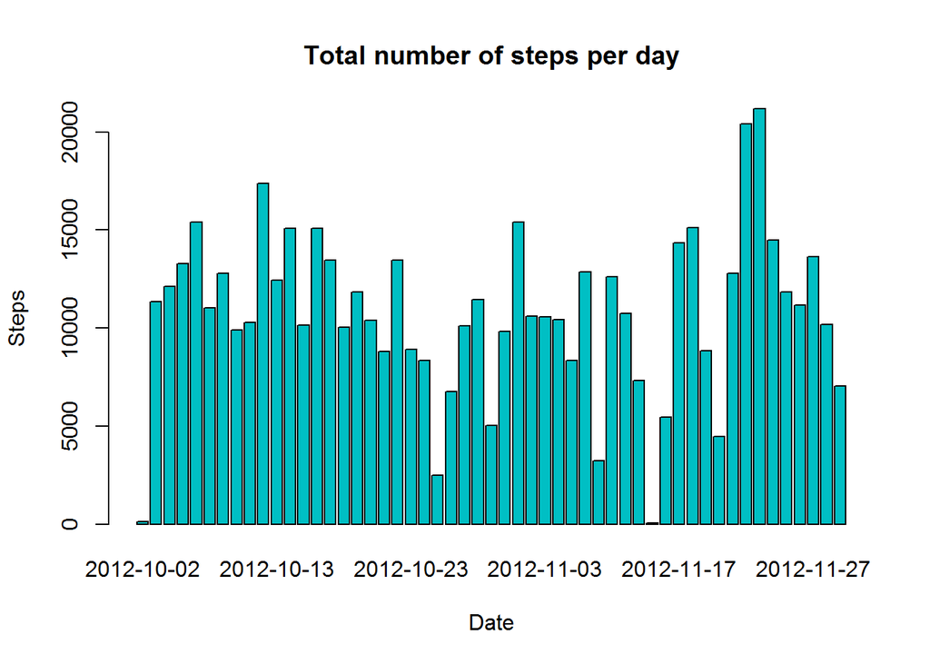

```r
stepsDate <- aggregate(steps ~ date, activityData, sum)
barplot(stepsDate$steps,
        names.arg=stepsDate$date,
        main="Total number of steps per day",
        xlab="Date",
        ylab="Steps",
        col="#00BFC4")
```

Our question is about mean and median of total number of steps, so check this:

```r
meanSteps <- mean(stepsDate$steps)
medianSteps <- median(stepsDate$steps)
```

Our results - mean…

```
## [1] 10766.19
```

and median

```
## [1] 10765
```

### What is the average daily activity pattern?

First task about this question is to make a time series plot (i.e. type = “l”) of the 5-minute interval (x-axis) and the average number of steps taken, averaged across all days (y-axis)

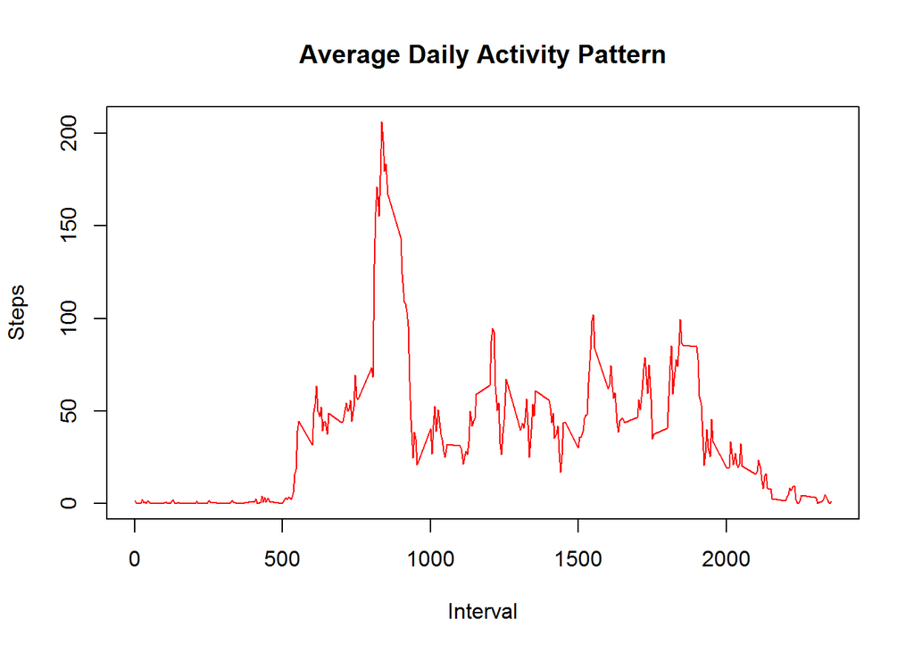

```r
stepsInterval <- aggregate(steps ~ interval, data = activityData, FUN = mean)
plot(stepsInterval, type = "l", main="Average Daily Activity Pattern", xlab="Interval", ylab="Steps", col="#FE0000")
```

Second task is to answer on question: Which 5-minute interval, on average across all the days in the dataset, contains the maximum number of steps?

```r
stepsInterval$interval[which.max(stepsInterval$steps)]
```

```
## [1] 835
```

### Missing values

Last part is to manage missing values in our dataset.

#### 1.) Calculate and report the total number of missing values in the dataset (i.e. the total number of rows with “NA”)

To calculate this, we can assing new variable:

```r
missingValues <- sum(is.na(activityData$steps))
```

And the result is:

```
## [1] 2304
```

#### 2.) Devise a strategy for filling in all of the missing values in the dataset. The strategy does not need to be sophisticated. For example, you could use the mean/median for that day, or the mean for that 5-minute interval, etc.

We can use as we can read in above example - mean for that 5-minute interval:

```r
fillNA <- data.frame(activityData$steps)
fillNA[is.na(fillNA),] <- ceiling(tapply(X=activityData$steps,
                                         INDEX=activityData$interval,
                                         FUN=mean,
                                         na.rm=TRUE))
```

#### 3.) Create a new dataset that is equal to the original dataset but with the missing data filled in.

To do this, we create new variable with data:

```r
activityDataNew <- cbind(fillNA, activityData[,2:3])
colnames(activityDataNew) <- c("steps", "date", "interval")
```

### 4.) Make a histogram of the total number of steps taken each day and Calculate and report the mean and median total number of steps taken per day.

We must to create new variable, preapare data to plot and do the plot:

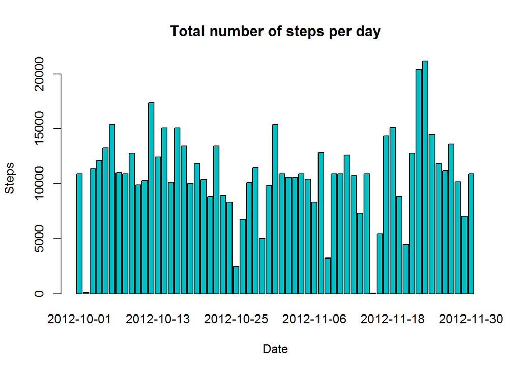

```r
stepsDateNew <- aggregate(steps ~ date, activityDataNew, sum)
barplot(stepsDateNew$steps,
         names.arg=stepsDateNew$date,
         main="Total number of steps per day",
         xlab="Date",
         ylab="Steps",
         col="#00BFC4")
```

Our question is about mean and median of total number of steps, so check this:

```r
meanStepsNew <- mean(stepsDateNew$steps)
medianStepsNew <- median(stepsDateNew$steps)
```

Our results - mean…

```
## [1] 10784.92
```

and median

```
## [1] 10909
```

Answering on questions to this task:

- Do these values differ from the estimates from the first part of the assignment?

Mean of steps taken by day before our “filling the NA” was 10766.19, now is 10784.92. Median of step taken by the day before our “filling the NA” was 10765, now is 10909.

### Are there differences in activity patterns between weekdays and weekends?

#### 1.) Create a new factor variable in the dataset with two levels – “weekday” and “weekend” indicating whether a given date is a weekday or weekend day.

!!Notice!! To create this document in my environment I needed to use Polish words for weekend (“sobota” and “niedziela”). To test this script yourself - you must to change both words into English “Saturday” and “Sunday”!!

```r
typeOfDay <- function(date) {
    if (weekdays(as.Date(date)) %in% c("sobota", "niedziela")) {
        "weekend"
    } else {
        "weekday"
    }
}
activityDataNew$daytype <- as.factor(sapply(X=activityDataNew$date, FUN=typeOfDay))
```

#### 2.) Make a panel plot containing a time series plot (i.e. type = “l”) of the 5-minute interval (x-axis) and the average number of steps taken, averaged across all weekday days or weekend days (y-axis).

First we must to calculate a mean of steps taken for each 5-minute interval and save into new variable:

```r
finalData <- aggregate(data=activityDataNew,
                       steps ~ daytype + interval,
                       FUN=mean)
```

Now we can make a final plot:

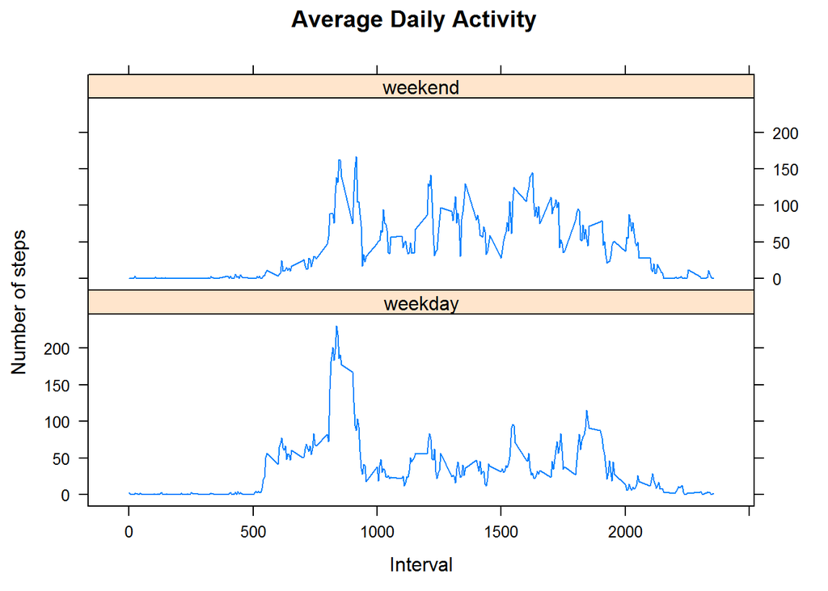

```r
library("lattice")
xyplot(
     type="l",
     data=finalData,
     steps ~ interval | daytype,
     main="Average Daily Activity",
     xlab="Interval",
     ylab="Number of steps",
     layout=c(1,2)
)
```